# 2020 & 2024 election studies: data, exclusions and descriptive results

2026-10-08

This document is generated from the processed data in this repo (`combined/` plus each study’s `processed/` tables; see `DATA.md`). The main figures use the **main** session set (defined under *Session sets*), a word-level RT window of **180–5000 ms**, and Maze correct-first-try only = **TRUE**. These are `params` in the YAML header, so the same document can be re-rendered under other choices:

```
rmarkdown::render("analysis/descriptives.Rmd", params = list(main_set = "comprehension"))
```

```r
analysis_data <- load_analysis_data(list(
  rt_min = params$rt_min, rt_max = params$rt_max,
  max_words_too_fast = params$max_words_too_fast, maze_accuracy_min = params$maze_accuracy_min
))
sessions <- analysis_data$sessions
cloze <- analysis_data$cloze
reading <- analysis_data$reading
critical_words <- analysis_data$critical_words
recall <- analysis_data$recall
step_cols <- analysis_data$step_cols
participant_steps <- analysis_data$participant_steps
session_sets <- analysis_data$session_sets
expectation_sets <- analysis_data$expectation_sets
kept_sessions <- session_sets[[params$main_set]]
```

# Data

Two between-participant experiments around the 2020 (Harris for vice president) and 2024 (Harris for president) US elections. Each session gives event-expectation sliders plus **one** critical trial of one task (cloze, A-Maze, SPR, or the 2020-only mazerace control), in a random order, before (pre) or after (post) the election. `OVERVIEW.md` has the design side by side; `METHODS-SUMMARY.md` has sourced detail.

```r
sessions |>
  count(study, task, round) |>
  pivot_wider(names_from = round, values_from = n) |>
  show_table("All sessions (before exclusions) by study, task and round")
```

All sessions (before exclusions) by study, task and round

| study | task | pre | post |
| --- | --- | --- | --- |
| 2020 | cloze | 962 | 870 |
| 2020 | maze | 1,173 | 1,234 |
| 2020 | mazerace | 1,136 | 1,272 |
| 2020 | spr | 1,377 | 1,167 |
| 2024 | cloze | 495 | 514 |
| 2024 | maze | 297 | 283 |
| 2024 | spr | 498 | 491 |

# Exclusions

## Default exclusions

Decided 2026-10-07 (from the candidate counts further down). Applied identically to both studies, in this order; each column counts sessions newly removed by that step.

Participant-wide (all tasks and the event sliders):

1. **Incomplete**: 2024 runs without the end-of-study survey (2020 Ibex logs only contain submitted sessions).
2. **Repeat participant**: 2020: same IP pseudonym or MTurk worker as an earlier session in the round, or the worker took part pre-election (`excl_repeat_ip`, `excl_repeat_worker`, `excl_worker_in_pre_round`); 2024: same `workerid` submitted twice, or removed by the original’s Prolific-ID check.
3. **Not a native English speaker** (self-report).
4. **Not a US citizen or not a US resident** (self-report). The original 2020 pipeline did not apply this; 2024’s did.

Reading tasks only (Maze, SPR, mazerace), counted over the critical trial: the context sentence and both critical sentences (the practice item is not used).

5. **No critical trial**: a few 2024 reading sessions never completed the critical trial (all already excluded by the original pipeline).
6. **More than 2 words too fast** (RT under 180 ms).
7. **Maze accuracy below 0.8** (Maze and mazerace): proportion of words chosen correctly on the first try.

Cloze only:

8. **Nonsense completion** (`cloze_nonsense`; see `DATA.md`): blank, only “yes”/“no”/a number, a pasted ID, text copied from the context sentence, or a single word that doesn’t continue the sentence.

Event expectations: every step above applies to the sliders too, including the task-quality steps 5–8. A session that failed its task’s quality check is treated as an inattentive or not-good-faith participant, so their slider answers are dropped along with their task data (2020 sessions failing these checks put far more on “someone else”). In addition, sessions with **all sliders at 0** have undefined probabilities and are left out of the expectation figures; their task data is kept.

**Bots** have no direct signal: 2020’s bot-screening question had the same value in every session, and 2024 had none. Steps 6 and 7 are the proxies for reading tasks, and step 8 for cloze.

```r
# The steps themselves are defined in analysis/analysis_data.R.
# Sequential: count each session at the first step that removes it.
first_step <- sessions |>
  select(study, round, task, session_id, all_of(step_cols)) |>
  pivot_longer(all_of(step_cols), names_to = "step", values_to = "flag") |>
  filter(flag) |>
  slice_min(step, by = session_id) |>
  count(study, round, task, step) |>
  pivot_wider(names_from = step, values_from = n, values_fill = 0)
sequential <- sessions |>
  count(study, round, task, name = "all_sessions") |>
  left_join(first_step, by = c("study", "round", "task")) |>
  left_join(count(filter(sessions, !excl_main), study, round, task, name = "kept"),
            by = c("study", "round", "task")) |>
  mutate(across(where(is.numeric), \(x) coalesce(x, 0L)))
for (step in setdiff(step_cols, names(sequential))) sequential[[step]] <- 0L
sequential <- select(sequential, study, task, round, all_sessions, all_of(step_cols), kept)
stopifnot(all(sequential$all_sessions - rowSums(select(sequential, all_of(step_cols))) == sequential$kept))
sequential |>
  mutate(round = factor(round, levels = round_levels)) |>
  arrange(study, task, round) |>
  show_table("Default exclusions, applied in order (sessions removed at each step)")
```

Default exclusions, applied in order (sessions removed at each step)

| study | task | round | all_sessions | step_1_incomplete | step_2_repeat | step_3_not_native | step_4_not_us | step_5_no_critical_trial | step_6_too_fast | step_7_maze_accuracy | step_8_cloze_nonsense | kept |
| --- | --- | --- | --- | --- | --- | --- | --- | --- | --- | --- | --- | --- |
| 2020 | cloze | pre | 962 | 0 | 459 | 37 | 33 | 0 | 0 | 0 | 82 | 351 |
| 2020 | cloze | post | 870 | 0 | 676 | 22 | 13 | 0 | 0 | 0 | 55 | 104 |
| 2020 | maze | pre | 1,173 | 0 | 604 | 43 | 38 | 0 | 81 | 67 | 0 | 340 |
| 2020 | maze | post | 1,234 | 0 | 986 | 11 | 11 | 0 | 44 | 53 | 0 | 129 |
| 2020 | mazerace | pre | 1,136 | 0 | 561 | 38 | 53 | 0 | 81 | 82 | 0 | 321 |
| 2020 | mazerace | post | 1,272 | 0 | 1,010 | 11 | 24 | 0 | 43 | 77 | 0 | 107 |
| 2020 | spr | pre | 1,377 | 0 | 625 | 62 | 43 | 0 | 119 | 0 | 0 | 528 |
| 2020 | spr | post | 1,167 | 0 | 894 | 15 | 13 | 0 | 74 | 0 | 0 | 171 |
| 2024 | cloze | pre | 495 | 0 | 1 | 8 | 1 | 0 | 0 | 0 | 7 | 478 |
| 2024 | cloze | post | 514 | 0 | 5 | 11 | 1 | 0 | 0 | 0 | 15 | 482 |
| 2024 | maze | pre | 297 | 3 | 3 | 2 | 1 | 0 | 3 | 31 | 0 | 254 |
| 2024 | maze | post | 283 | 1 | 2 | 3 | 1 | 0 | 2 | 25 | 0 | 249 |
| 2024 | spr | pre | 498 | 2 | 2 | 11 | 1 | 0 | 39 | 0 | 0 | 443 |
| 2024 | spr | post | 491 | 4 | 3 | 8 | 3 | 0 | 27 | 0 | 0 | 446 |

## Comprehension accuracy

One comprehension question followed each critical Maze, SPR and mazerace trial. The 2020 code defines a question for each critical sentence, but the logs hold exactly one per session, and in every 2020 Maze/SPR session it is the question about **sentence 1** (checked against the stimulus file). Neither 2020 pipeline used the answers; 2024’s required a correct answer for Maze and SPR. Here it is a robustness set, not a default exclusion.

```r
comprehension_sessions <- sessions |>
  filter(is_reading, !excl_main)
comprehension_sessions |>
  group_by(study, task, round) |>
  summarize(n = n(), no_answer = sum(comprehension_n == 0),
            prop_correct = round(mean(comprehension_correct), 2), .groups = "drop") |>
  pivot_wider(names_from = round, values_from = c(n, no_answer, prop_correct)) |>
  show_table("Comprehension accuracy (sessions kept by the default exclusions; no answer counts as incorrect)")
```

Comprehension accuracy (sessions kept by the default exclusions; no answer counts as incorrect)

| study | task | n_pre | n_post | no_answer_pre | no_answer_post | prop_correct_pre | prop_correct_post |
| --- | --- | --- | --- | --- | --- | --- | --- |
| 2020 | maze | 340 | 129 | 0 | 0 | 0.79 | 0.76 |
| 2020 | mazerace | 321 | 107 | 0 | 0 | 0.89 | 0.97 |
| 2020 | spr | 528 | 171 | 0 | 0 | 0.85 | 0.80 |
| 2024 | maze | 254 | 249 | 0 | 0 | 0.94 | 0.94 |
| 2024 | spr | 443 | 446 | 0 | 0 | 0.93 | 0.93 |

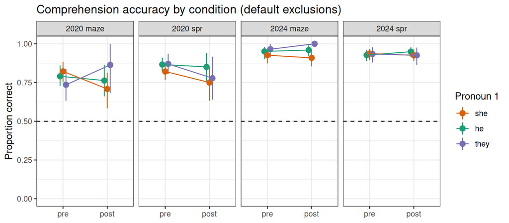

```r
comprehension_sessions |>
  filter(task %in% c("maze", "spr")) |>
  inner_join(distinct(critical_words, session_id, pro1_type), by = "session_id", relationship = "one-to-one") |>
  ggplot(aes(x = round, y = as.numeric(comprehension_correct), color = pro1_type, group = pro1_type)) +
  line_with_errorbars(dodge) +
  facet_wrap(~ paste(study, task), nrow = 1) +
  pronoun_scale +
  labs(x = NULL, y = "Proportion correct", color = "Pronoun 1",
       title = "Comprehension accuracy by condition (default exclusions)")+
  coord_cartesian(ylim=c(0,1))+geom_hline(aes(yintercept=.5),lty="dashed")
```

## Maze accuracy

Each session’s accuracy is the proportion of its critical-trial Maze words chosen correctly on the first try. Chance is 0.5. Shown for sessions that pass the participant-wide steps (1–4), before the reading-task steps.

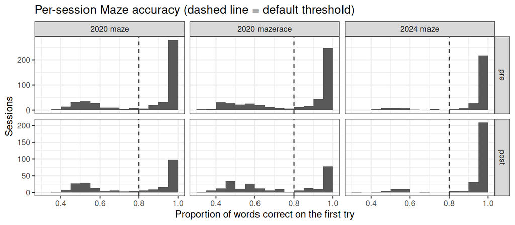

```r
sessions |>
  filter(is_maze, !excl_participant, !step_5_no_critical_trial) |>
  ggplot(aes(x = maze_accuracy)) +
  geom_histogram(binwidth = .05, boundary = 0) +
  geom_vline(xintercept = params$maze_accuracy_min, linetype = "dashed") +
  facet_grid(round ~ paste(study, task), scales = "free_y") +
  labs(x = "Proportion of words correct on the first try", y = "Sessions",
       title = "Per-session Maze accuracy (dashed line = default threshold)")
```

## RT plausibility

How many of each session’s critical-trial words fall outside 180–5000 ms? Is it close to all-or-nothing per session, or are there many borderline sessions with a few out-of-window words? A critical trial has about 70 words in 2020 Maze and SPR, 36 in mazerace, and about 49 in 2024. Shown for sessions that pass the participant-wide steps (1–4).

```r
rt_direction_counts <- sessions |>
  filter(is_reading, !excl_participant, !step_5_no_critical_trial) |>
  select(study, round, task, session_id, words, too_fast = n_too_fast, too_slow = n_too_slow) |>
  pivot_longer(c(too_fast, too_slow), names_to = "direction", values_to = "n_words") |>
  mutate(direction = recode(direction,
                            too_fast = paste0("too fast (< ", params$rt_min, " ms)"),
                            too_slow = paste0("too slow (> ", params$rt_max, " ms)")),
         prop_words = n_words / words,
         panel = paste(study, task))
count_bins <- c("0", "1", "2", "3–5", "6–10", "11–20", "> 20")
rt_direction_counts <- rt_direction_counts |>
  mutate(n_words_bin = cut(n_words, breaks = c(-Inf, 0, 1, 2, 5, 10, 20, Inf), labels = count_bins))
stopifnot(!anyNA(rt_direction_counts$n_words_bin))
```

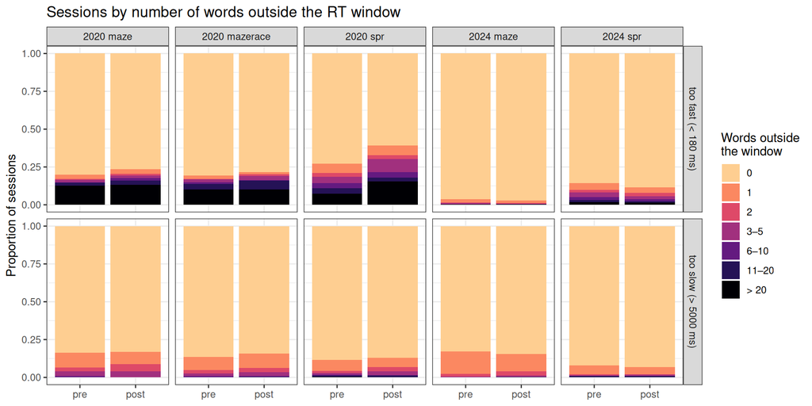

```r
ggplot(rt_direction_counts, aes(x = round, fill = n_words_bin)) +
  geom_bar(position = "fill") +
  facet_grid(direction ~ panel) +
  scale_fill_viridis_d(option = "magma", direction = -1, end = .9) +
  labs(x = NULL, y = "Proportion of sessions", fill = "Words outside\nthe window",
       title = "Sessions by number of words outside the RT window")
```

The same counts as a proportion of each session’s words, for sessions with at least one such word (the bar chart above shows how many have none):

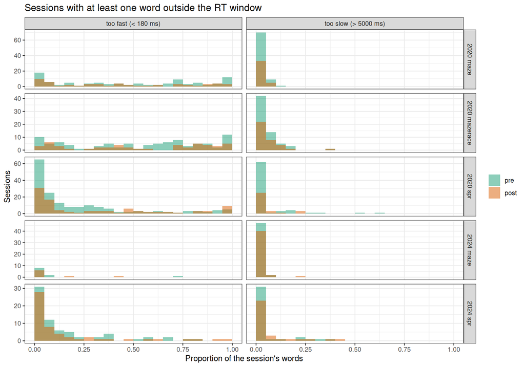

```r
ggplot(filter(rt_direction_counts, n_words > 0), aes(x = prop_words, fill = round)) +
  geom_histogram(binwidth = .05, boundary = 0, position = "identity", alpha = .5) +
  facet_grid(panel ~ direction, scales = "free_y") +
  scale_fill_brewer(palette = "Dark2") +
  labs(x = "Proportion of the session's words", y = "Sessions", fill = NULL,
       title = "Sessions with at least one word outside the RT window")
```

**2020 data quality.** Before any exclusions, 2020 has many sessions that click through fast: Maze accuracy near chance (0.5) with very short first-click RTs, and SPR words read in under 180 ms. These are much more common post-election. This looks like fast clicking, not a processing artefact: errors are equally common for left and right answers, and the same pattern holds on the practice item. The repeat-participant step removes most of these sessions; steps 6 and 7 remove the near-chance and fast-clicking group that remains. Fast clicking is close to all-or-nothing in 2020 Maze, but 2020 SPR has a borderline group with a few fast words, which is where the step 6 cutoff matters.

## Candidate exclusion criteria: how many each would remove

The counts the default was chosen from: how many sessions each candidate criterion would flag on its own. The base is sessions that pass steps 1–3 (complete, not a repeat participant, native English speaker); every count is out of that base. Measures are over the critical trial (no practice).

```r
# One logical column per criterion; NA where it doesn't apply to the task.
reading_only <- function(is_reading, flag) if_else(is_reading, flag, NA)
maze_only <- function(is_maze, flag) if_else(is_maze, flag, NA)
cloze_only <- function(task, flag) if_else(task == "cloze", flag, NA)
criteria <- sessions |>
  filter(!step_1_incomplete, !step_2_repeat, !step_3_not_native) |>
  mutate(
    no_trial = step_5_no_critical_trial,
    not_us = step_4_not_us,
    sliders_all_zero = sliders_all_zero,
    comprehension_wrong = reading_only(is_reading, !comprehension_correct),
    any_too_fast = reading_only(is_reading, no_trial | n_too_fast > 0),
    over_2_too_fast = reading_only(is_reading, no_trial | n_too_fast > 2),
    over_10pct_too_fast = reading_only(is_reading, no_trial | n_too_fast / words > .1),
    any_too_slow = reading_only(is_reading, no_trial | n_too_slow > 0),
    over_2_too_slow = reading_only(is_reading, no_trial | n_too_slow > 2),
    maze_accuracy_low = maze_only(is_maze, no_trial | !coalesce(maze_accuracy >= params$maze_accuracy_min, FALSE)),
    cloze_nonsense = cloze_only(task, step_8_cloze_nonsense)
  )
criterion_cols <- c("not_us", "sliders_all_zero", "comprehension_wrong", "any_too_fast", "over_2_too_fast",
                    "over_10pct_too_fast", "any_too_slow", "over_2_too_slow", "maze_accuracy_low",
                    "cloze_nonsense")
stopifnot(!anyNA(criteria$not_us), !anyNA(criteria$sliders_all_zero),
          # Every reading session has a value for every reading criterion.
          !anyNA(filter(criteria, is_reading)$any_too_fast))

criteria |>
  pivot_longer(all_of(criterion_cols), names_to = "criterion", values_to = "flagged") |>
  filter(!is.na(flagged)) |>
  group_by(criterion, study, task, round) |>
  summarize(cell = sprintf("%d (%.0f%%)", sum(flagged), 100 * mean(flagged)), .groups = "drop") |>
  mutate(criterion = factor(criterion, levels = criterion_cols),
         column = paste(study, task, round)) |>
  arrange(study, task, round) |>
  select(-study, -task, -round) |>
  pivot_wider(names_from = column, values_from = cell, values_fill = "–") |>
  arrange(criterion) |>
  show_table(paste0("Sessions flagged by each criterion on its own, n (% of base). ",
                    "RT window ", params$rt_min, "–", params$rt_max, " ms; Maze accuracy threshold ",
                    params$maze_accuracy_min, "; – = does not apply"))
```

Sessions flagged by each criterion on its own, n (% of base). RT window 180–5000 ms; Maze accuracy threshold 0.8; – = does not apply

| criterion | 2020 cloze pre | 2020 cloze post | 2020 maze pre | 2020 maze post | 2020 mazerace pre | 2020 mazerace post | 2020 spr pre | 2020 spr post | 2024 cloze pre | 2024 cloze post | 2024 maze pre | 2024 maze post | 2024 spr pre | 2024 spr post |
| --- | --- | --- | --- | --- | --- | --- | --- | --- | --- | --- | --- | --- | --- | --- |
| not_us | 33 (7%) | 13 (8%) | 38 (7%) | 11 (5%) | 53 (10%) | 24 (10%) | 43 (6%) | 13 (5%) | 1 (0%) | 1 (0%) | 1 (0%) | 1 (0%) | 1 (0%) | 3 (1%) |
| sliders_all_zero | 4 (1%) | 0 (0%) | 2 (0%) | 1 (0%) | 6 (1%) | 2 (1%) | 0 (0%) | 2 (1%) | 0 (0%) | 0 (0%) | 0 (0%) | 2 (1%) | 0 (0%) | 1 (0%) |
| comprehension_wrong | – | – | 152 (29%) | 88 (37%) | 59 (11%) | 19 (8%) | 129 (19%) | 63 (24%) | – | – | 21 (7%) | 18 (6%) | 35 (7%) | 34 (7%) |
| any_too_fast | – | – | 102 (19%) | 54 (23%) | 99 (18%) | 58 (23%) | 182 (26%) | 98 (38%) | – | – | 11 (4%) | 8 (3%) | 69 (14%) | 54 (11%) |
| over_2_too_fast | – | – | 84 (16%) | 45 (19%) | 87 (16%) | 52 (21%) | 123 (18%) | 75 (29%) | – | – | 3 (1%) | 2 (1%) | 39 (8%) | 27 (6%) |
| over_10pct_too_fast | – | – | 76 (14%) | 38 (16%) | 84 (16%) | 49 (20%) | 89 (13%) | 48 (19%) | – | – | 1 (0%) | 2 (1%) | 26 (5%) | 18 (4%) |
| any_too_slow | – | – | 86 (16%) | 40 (17%) | 77 (14%) | 40 (16%) | 81 (12%) | 32 (12%) | – | – | 50 (17%) | 43 (16%) | 38 (8%) | 32 (7%) |
| over_2_too_slow | – | – | 20 (4%) | 10 (4%) | 16 (3%) | 10 (4%) | 20 (3%) | 10 (4%) | – | – | 2 (1%) | 3 (1%) | 7 (1%) | 9 (2%) |
| maze_accuracy_low | – | – | 163 (31%) | 102 (43%) | 179 (33%) | 136 (54%) | – | – | – | – | 34 (12%) | 27 (10%) | – | – |
| cloze_nonsense | 86 (18%) | 61 (35%) | – | – | – | – | – | – | 7 (1%) | 15 (3%) | – | – | – | – |

```r
criteria |>
  count(study, task, round, name = "base") |>
  pivot_wider(names_from = round, values_from = base) |>
  show_table("Base sessions (complete, not a repeat, native English speaker)")
```

Base sessions (complete, not a repeat, native English speaker)

| study | task | pre | post |
| --- | --- | --- | --- |
| 2020 | cloze | 466 | 172 |
| 2020 | maze | 526 | 237 |
| 2020 | mazerace | 537 | 251 |
| 2020 | spr | 690 | 258 |
| 2024 | cloze | 486 | 498 |
| 2024 | maze | 289 | 277 |
| 2024 | spr | 483 | 476 |

Do the reading-task criteria pick out the same sessions? For each reading session, how many of these four it fails: comprehension wrong, more than 2 words too fast, more than 2 words too slow, Maze accuracy low (Maze and mazerace only, so SPR sessions can fail at most three).

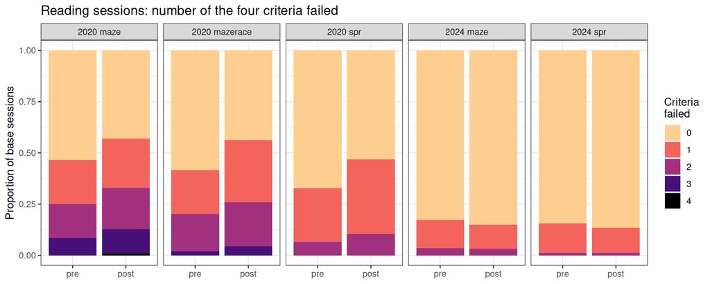

```r
overlap_cols <- c("comprehension_wrong", "over_2_too_fast", "over_2_too_slow", "maze_accuracy_low")
criteria_overlap <- criteria |>
  filter(is_reading) |>
  mutate(n_failed = rowSums(across(all_of(overlap_cols)), na.rm = TRUE),
         panel = paste(study, task))
ggplot(criteria_overlap, aes(x = round, fill = factor(n_failed))) +
  geom_bar(position = "fill") +
  facet_wrap(~panel, nrow = 1) +
  scale_fill_viridis_d(option = "magma", direction = -1, end = .9) +
  labs(x = NULL, y = "Proportion of base sessions", fill = "Criteria\nfailed",
       title = "Reading sessions: number of the four criteria failed")
```

The most common combinations of failed criteria (reading sessions, pooled over rounds):

```r
criteria_overlap |>
  filter(n_failed > 0) |>
  mutate(combination = pmap_chr(across(all_of(overlap_cols)), \(...) {
    flags <- c(...)
    paste(overlap_cols[coalesce(flags, FALSE)], collapse = " + ")
  })) |>
  count(study, task, combination) |>
  left_join(count(criteria_overlap, study, task, name = "base"), by = c("study", "task")) |>
  mutate(prop_of_base = round(n / base, 2)) |>
  select(-base) |>
  arrange(study, task, desc(n)) |>
  slice_head(n = 5, by = c(study, task)) |>
  show_table("Top 5 combinations of failed criteria per study and task (prop_of_base: share of that study x task's base sessions)")
```

Top 5 combinations of failed criteria per study and task (prop_of_base: share of that study x task’s base sessions)

| study | task | combination | n | prop_of_base |
| --- | --- | --- | --- | --- |
| 2020 | maze | comprehension_wrong | 101 | 0.13 |
| 2020 | maze | comprehension_wrong + over_2_too_fast + maze_accuracy_low | 63 | 0.08 |
| 2020 | maze | comprehension_wrong + maze_accuracy_low | 62 | 0.08 |
| 2020 | maze | maze_accuracy_low | 62 | 0.08 |
| 2020 | maze | over_2_too_fast + maze_accuracy_low | 61 | 0.08 |
| 2020 | mazerace | maze_accuracy_low | 143 | 0.18 |
| 2020 | mazerace | over_2_too_fast + maze_accuracy_low | 120 | 0.15 |
| 2020 | mazerace | comprehension_wrong | 39 | 0.05 |
| 2020 | mazerace | comprehension_wrong + maze_accuracy_low | 18 | 0.02 |
| 2020 | mazerace | comprehension_wrong + over_2_too_fast + maze_accuracy_low | 17 | 0.02 |
| 2020 | spr | over_2_too_fast | 130 | 0.14 |
| 2020 | spr | comprehension_wrong | 121 | 0.13 |
| 2020 | spr | comprehension_wrong + over_2_too_fast | 66 | 0.07 |
| 2020 | spr | over_2_too_slow | 23 | 0.02 |
| 2020 | spr | comprehension_wrong + over_2_too_slow | 5 | 0.01 |
| 2024 | maze | maze_accuracy_low | 42 | 0.07 |
| 2024 | maze | comprehension_wrong | 29 | 0.05 |
| 2024 | maze | comprehension_wrong + maze_accuracy_low | 10 | 0.02 |
| 2024 | maze | over_2_too_fast + maze_accuracy_low | 5 | 0.01 |
| 2024 | maze | over_2_too_slow + maze_accuracy_low | 4 | 0.01 |
| 2024 | spr | comprehension_wrong | 57 | 0.06 |
| 2024 | spr | over_2_too_fast | 56 | 0.06 |
| 2024 | spr | over_2_too_slow | 14 | 0.01 |
| 2024 | spr | comprehension_wrong + over_2_too_fast | 10 | 0.01 |
| 2024 | spr | comprehension_wrong + over_2_too_slow | 2 | 0.00 |

# Session sets

All figures draw on one of these sets of sessions. The main figures use **main**; the robustness section compares all of them.

- **main**: the default exclusions above.
- **comprehension**: main, plus a correct comprehension answer (reading tasks).
- **strict_timing**: main, plus no word at all outside 180–5000 ms in the critical trial (reading tasks).
- **high_attention**: the strictest set, for participants paying the most attention: main, plus comprehension *and* strict_timing (reading tasks), and, for every task, dropping sessions whose event sliders were all left at 0 (in main, those sessions keep their task data).
- **no_us_exclusion**: main without step 4 (citizenship/residence).
- **all_pronoun_clozes**: main, plus cloze sessions dropped only as nonsense (step 8) whose completion has a pronoun referring to the office-holder. Checks that the nonsense judgments (pasted, generated-sounding or garbled text) don’t drive the pronoun results; it differs from main only for cloze.
- **task_first**: main, restricted to sessions that did the critical task before the event sliders.
- **original**: each study’s original pipeline rules (`excl_task_original`; `excl_expectations_original` for the sliders).

Cloze sessions are the same in main, comprehension and strict_timing; in high_attention they differ from main only by the slider rule. The event-expectation figures use the same sets (minus sessions with all sliders at 0), except original, which uses each study’s original slider rule (`excl_expectations_original`).

```r
# The sets themselves are defined in analysis/analysis_data.R.
imap(session_sets, \(ids, set) count(filter(sessions, session_id %in% ids), study, round, task) |>
       mutate(set = set)) |>
  list_rbind() |>
  mutate(set = factor(set, levels = set_levels)) |>
  pivot_wider(names_from = set, values_from = n, values_fill = 0) |>
  arrange(study, task, round) |>
  show_table("Sessions in each set (task data), by study, task and round")
```

Sessions in each set (task data), by study, task and round

| study | round | task | main | comprehension | strict_timing | high_attention | no_us_exclusion | all_pronoun_clozes | task_first | original |
| --- | --- | --- | --- | --- | --- | --- | --- | --- | --- | --- |
| 2020 | pre | cloze | 351 | 351 | 351 | 349 | 380 | 351 | 223 | 462 |
| 2020 | post | cloze | 104 | 104 | 104 | 104 | 111 | 104 | 60 | 172 |
| 2020 | pre | maze | 340 | 269 | 281 | 223 | 363 | 340 | 214 | 339 |
| 2020 | post | maze | 129 | 98 | 110 | 87 | 135 | 129 | 76 | 136 |
| 2020 | pre | mazerace | 321 | 287 | 280 | 250 | 357 | 321 | 209 | 356 |
| 2020 | post | mazerace | 107 | 104 | 93 | 88 | 115 | 107 | 74 | 142 |
| 2020 | pre | spr | 528 | 448 | 413 | 362 | 567 | 528 | 357 | 448 |
| 2020 | post | spr | 171 | 136 | 128 | 104 | 183 | 171 | 114 | 135 |
| 2024 | pre | cloze | 478 | 478 | 478 | 478 | 479 | 480 | 323 | 485 |
| 2024 | post | cloze | 482 | 482 | 482 | 482 | 483 | 486 | 337 | 497 |
| 2024 | pre | maze | 254 | 240 | 205 | 194 | 255 | 254 | 164 | 244 |
| 2024 | post | maze | 249 | 235 | 209 | 195 | 250 | 249 | 156 | 235 |
| 2024 | pre | spr | 443 | 413 | 377 | 351 | 444 | 443 | 295 | 447 |
| 2024 | post | spr | 446 | 417 | 389 | 362 | 449 | 446 | 310 | 439 |

# Event expectations

Each participant moved three sliders (Democratic candidate, Republican candidate, someone else); probabilities are each slider divided by their sum. In 2020, a random half were asked about the vice presidency (Harris vs. Pence) and half about the presidency (Biden vs. Trump). The same exclusions apply as for the task data, so sessions that failed their task’s quality check (inattentive or not-good-faith participants) are left out; see *Default exclusions*. Sessions with all sliders at 0 have no probabilities and are left out too.

Grey symbols are what forecasters and betting markets said at the time (`analysis/external_expectations.csv`, which records each value’s source, time window and how it was extracted): the point is the mean over the round’s collection window and the bar the range. In 2020 the vice-presidency question has the same answer as the presidency question (Harris is vice president exactly when Biden wins), so the same reference values apply to both. After the election there are no forecasts; the markets still gave Trump 6–12% after the 2020 race was called, while the 2024 market had already resolved for Trump before the post wave.

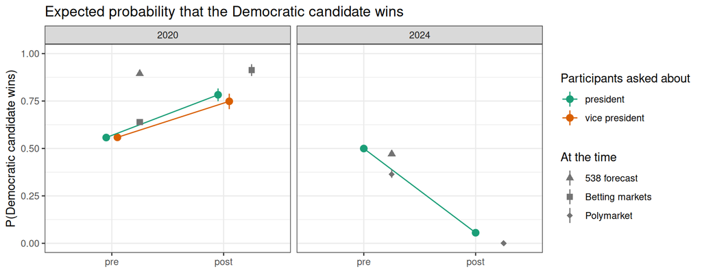

```r
expectation_plot_data <- sessions |>
  filter(session_id %in% expectation_sets[[params$main_set]]) |>
  mutate(target = recode(expectation_target, vice_president = "vice president"),
         panel = paste(study, target))
external_expectations <- read_csv(here("analysis", "external_expectations.csv"),
                                  col_types = cols(study = col_character())) |>
  mutate(round = factor(round, levels = round_levels),
         # Drop the parenthesized list of markets from the legend label.
         source = str_remove(source, " \\(.*\\)"))
stopifnot(all(external_expectations$study %in% c("2020", "2024")),
          !anyNA(external_expectations$round),
          with(external_expectations, all(p_dem_low <= p_dem & p_dem <= p_dem_high)))
ggplot(expectation_plot_data, aes(x = round, y = expect_prob_dem, color = target, group = target)) +
  line_with_errorbars(dodge) +
  geom_pointrange(data = external_expectations,
                  mapping = aes(x = round, y = p_dem, ymin = p_dem_low, ymax = p_dem_high, shape = source),
                  inherit.aes = FALSE, color = "grey45", position = position_nudge(x = .25)) +
  facet_wrap(~study) +
  scale_color_brewer(palette = "Dark2") +
  scale_shape_manual(values = c(17, 15, 18)) +
  coord_cartesian(ylim = c(0, 1)) +
  labs(x = NULL, y = "P(Democratic candidate wins)", color = "Participants asked about", shape = "At the time",
       title = "Expected probability that the Democratic candidate wins")
```

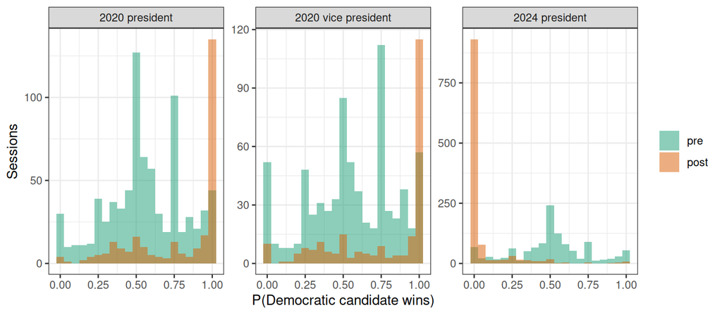

```r
ggplot(expectation_plot_data, aes(x = expect_prob_dem, fill = round)) +
  geom_histogram(binwidth = .05, position = "identity", alpha = .5) +
  facet_wrap(~panel, scales = "free_y", nrow = 1) +
  scale_fill_brewer(palette = "Dark2") +
  labs(x = "P(Democratic candidate wins)", y = "Sessions", fill = NULL)
```

National polling averages at the time (538; vote shares, not probabilities, so not plotted): 2020 pre, Biden 52.1% vs. Trump 43.0% (Oct 30) and 51.8% vs. 43.4% (Nov 3); 2024 pre, Harris 47.9% vs. Trump 46.8% (Oct 31). Sources: archived `presidential_poll_averages_2020.csv` and `presidential_general_averages.csv` from projects.fivethirtyeight.com (Wayback Machine).

# Cloze completions

Each session contributes one completion, so proportions are over sessions. Two views (columns described in `DATA.md`):

- **First target pronoun**: among completions with at least one pronoun referring to the target office-holder (2020: the vice president; 2024: the president), which kind comes first (`first_coref_pronoun`).
- **References anywhere**: the share of completions containing each kind of reference, anywhere in the completion; one completion can count in several categories.

```r
cloze_levels <- c("she", "he", "they", "hedged", "female_candidate_name", "male_candidate_name",
                  "other_candidate_name", "target_office_np", "other_office_np", "generic_np", "other", "blank")
pronoun_codes <- c("she", "he", "they", "hedged")
pronoun_code_scale <- scale_color_manual(values = c(pronoun_colors, hedged = "grey40"),
                                         breaks = c(names(pronoun_colors), "hedged"))

# One row per session x code: 1 if the session's completion has that code.
code_indicators <- function(cloze_df, code_column) {
  cloze_df |>
    mutate(code = factor(.data[[code_column]], levels = cloze_levels)) |>
    select(study, round, session_id, code) |>
    mutate(present = 1) |>
    complete(nesting(study, round, session_id), code, fill = list(present = 0))
}
# Completions with a target-office pronoun only: 1 if it is the first one.
first_pronoun_indicators <- function(cloze_df) {
  cloze_df |>
    filter(first_coref_pronoun != "none") |>
    mutate(code = factor(first_coref_pronoun, levels = pronoun_codes)) |>
    select(study, round, session_id, code) |>
    mutate(present = 1) |>
    complete(nesting(study, round, session_id), code, fill = list(present = 0))
}
cloze_kept <- filter(cloze, session_id %in% kept_sessions)
stopifnot(!anyNA(factor(cloze_kept$cloze_code, levels = cloze_levels)),
          all(cloze_kept$first_coref_pronoun %in% c(pronoun_codes, "none")))
first_pronouns <- first_pronoun_indicators(cloze_kept)
stopifnot(all(count(first_pronouns, session_id)$n == length(pronoun_codes)))

cloze_kept |>
  summarize(completions = n(), with_target_pronoun = sum(first_coref_pronoun != "none"), .by = c(study, round)) |>
  arrange(study, round) |>
  show_table("Completions with at least one pronoun referring to the target office-holder")
```

Completions with at least one pronoun referring to the target office-holder

| study | round | completions | with_target_pronoun |
| --- | --- | --- | --- |
| 2020 | pre | 351 | 80 |
| 2020 | post | 104 | 24 |
| 2024 | pre | 478 | 208 |
| 2024 | post | 482 | 227 |

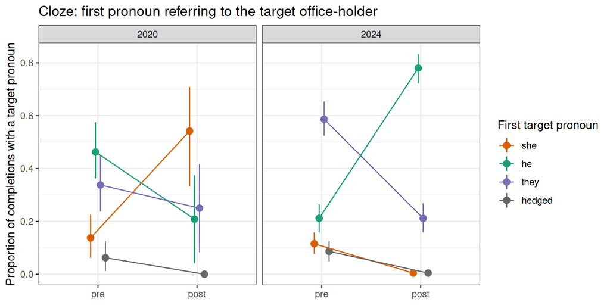

```r
ggplot(first_pronouns, aes(x = round, y = present, color = code, group = code)) +
  line_with_errorbars(dodge) +
  facet_wrap(~study) +
  pronoun_code_scale +
  labs(x = NULL, y = "Proportion of completions with a target pronoun", color = "First target pronoun",
       title = "Cloze: first pronoun referring to the target office-holder")
```

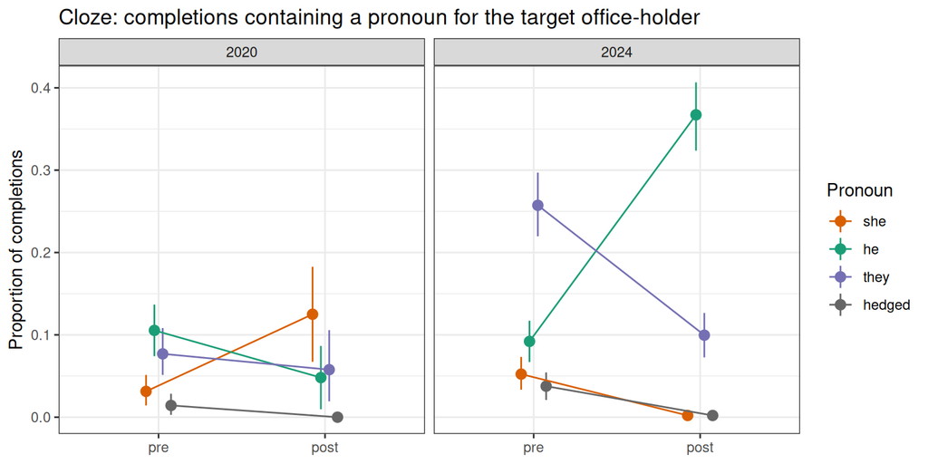

```r
# Each kind of reference, anywhere in the completion (repeats allowed).
reference_columns <- c(
  "she (target)" = "coref_she", "he (target)" = "coref_he", "they (target)" = "coref_they",
  "hedged (target)" = "coref_hedge",
  "Harris" = "has_female_candidate_name", "male candidate (target office)" = "has_male_candidate_name",
  "target office NP" = "has_target_office_np",
  "other-office candidate (2020: Biden, Trump)" = "has_other_candidate_name",
  "other office NP" = "has_other_office_np", "pronoun for other office-holder" = "any_coref_other",
  "generic NP (winner, candidate)" = "has_generic_np"
)
references_anywhere <- cloze_kept |>
  mutate(any_coref_other = coref_other_she | coref_other_he | coref_other_they | coref_other_hedge) |>
  select(study, round, session_id, all_of(reference_columns)) |>
  pivot_longer(-c(study, round, session_id), names_to = "reference", values_to = "present") |>
  mutate(reference = factor(reference, levels = names(reference_columns)), present = as.numeric(present))
stopifnot(!anyNA(references_anywhere$present))

ggplot(filter(references_anywhere, str_detect(reference, "\\(target\\)$")),
       aes(x = round, y = present, color = str_remove(reference, " \\(target\\)"),
           group = reference)) +
  line_with_errorbars(dodge) +
  facet_wrap(~study) +
  pronoun_code_scale +
  labs(x = NULL, y = "Proportion of completions", color = "Pronoun",
       title = "Cloze: completions containing a pronoun for the target office-holder")
```

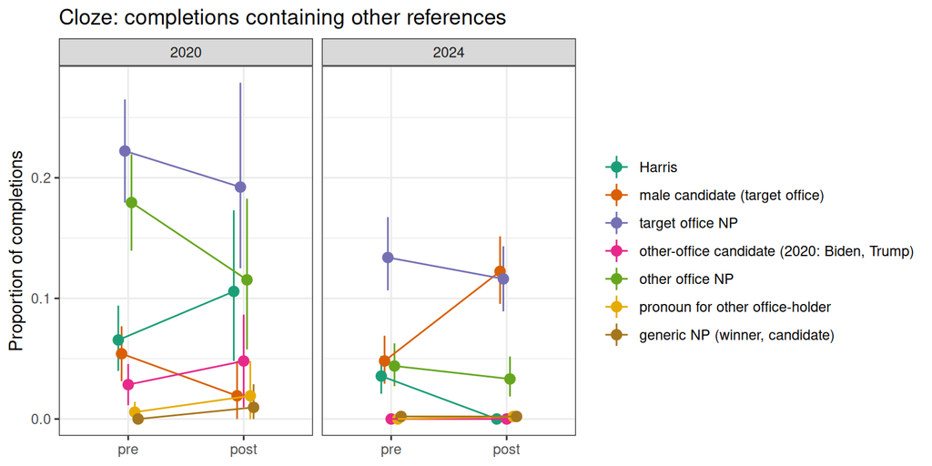

```r
ggplot(filter(references_anywhere, !str_detect(reference, "\\(target\\)$")),
       aes(x = round, y = present, color = reference, group = reference)) +
  line_with_errorbars(dodge) +
  facet_wrap(~study) +
  scale_color_brewer(palette = "Dark2") +
  labs(x = NULL, y = "Proportion of completions", color = NULL,
       title = "Cloze: completions containing other references")
```

The first referring expression of any kind (`cloze_code`), for reference:

```r
cloze_kept |>
  count(study, round, cloze_code) |>
  pivot_wider(names_from = c(study, round), values_from = n, values_fill = 0) |>
  show_table("Cloze completion counts (first reference)")
```

Cloze completion counts (first reference)

| cloze_code | 2020_pre | 2020_post | 2024_pre | 2024_post |
| --- | --- | --- | --- | --- |
| female_candidate_name | 21 | 11 | 15 | 0 |
| he | 37 | 5 | 39 | 169 |
| hedged | 4 | 0 | 17 | 1 |
| male_candidate_name | 15 | 2 | 18 | 56 |
| other | 106 | 37 | 166 | 144 |
| other_candidate_name | 8 | 4 | 0 | 0 |
| other_office_np | 50 | 10 | 21 | 15 |
| she | 9 | 10 | 24 | 1 |
| target_office_np | 75 | 19 | 61 | 51 |
| they | 26 | 5 | 116 | 44 |
| generic_np | 0 | 1 | 1 | 1 |

## Original vs. shared cloze coding

Each study’s original pipeline coded the completions its own way (`cloze_code_original`). The shared code (`cloze_code`) applies one rule to both: **the first referring expression in the completion**. The table maps each original label to the shared category it corresponds to, then counts how often the two agree.

How the originals differ from the shared rule:

- **Name vs. pronoun precedence.** When a completion has both, 2020’s original took the name, 2024’s took the pronoun; the shared code takes whichever comes first.
- **Office noun phrases.** 2020’s original had no category for “the vice president will…” (it was `none`); 2024 called it `ambiguous NP`. The shared code splits these by office: `target_office_np` (the office the item is about), `other_office_np` (the other office) and `generic_np` (“the winner”).
- **Hedges.** 2020’s original `both` and 2024’s `hedged` correspond to the shared `hedged`.
- **2024 “them” bug.** The 2024 original meant to skip “them” when it refers back to the plural in item 9’s prompt (“…many challenges, and one of”), but tested the response instead of the prompt, so those completions were coded as singular *they*.

```r
original_to_shared <- tribble(
  ~study, ~cloze_code_original, ~original_as_shared,
  "2020", "female", "she",
  "2020", "male", "he",
  "2020", "neutral", "they",
  "2020", "both", "hedged",
  "2020", "harris", "female_candidate_name",
  "2020", "pence", "male_candidate_name",
  "2020", "biden", "other_candidate_name",
  "2020", "trump", "other_candidate_name",
  "2020", "none", "other",
  "2024", "pronoun female", "she",
  "2024", "pronoun male", "he",
  "2024", "pronoun neutral", "they",
  "2024", "hedged", "hedged",
  "2024", "Harris", "female_candidate_name",
  "2024", "Trump", "male_candidate_name",
  "2024", "ambiguous NP", "target_office_np",
  "2024", "OTHER", "other"
)
cloze_original <- map(c("2020", "2024"), \(s) read_study(s, "cloze") |> mutate(study = s)) |>
  list_rbind() |>
  select(study, session_id, cloze_item, prompt, response, cloze_code_original, cloze_code) |>
  # Blank completions have no original code; both codings agree they are blank.
  left_join(original_to_shared, by = c("study", "cloze_code_original"), relationship = "many-to-one") |>
  mutate(original_as_shared = if_else(is.na(cloze_code_original), "blank", original_as_shared),
         round = factor(str_extract(session_id, "pre|post"), levels = round_levels))
stopifnot(!anyNA(cloze_original$original_as_shared),
          setequal(cloze_original$session_id, cloze$session_id))
cloze_original <- filter(cloze_original, session_id %in% kept_sessions)

cloze_original |>
  count(study, original = cloze_code_original, shared = cloze_code,
        agree = original_as_shared == cloze_code) |>
  arrange(study, agree, desc(n)) |>
  show_table("Original vs. shared coding (kept sessions); agree = the original label maps to the shared category")
```

Original vs. shared coding (kept sessions); agree = the original label maps to the shared category

| study | original | shared | agree | n |
| --- | --- | --- | --- | --- |
| 2020 | none | target_office_np | FALSE | 87 |
| 2020 | none | other_office_np | FALSE | 60 |
| 2020 | neutral | target_office_np | FALSE | 3 |
| 2020 | pence | female_candidate_name | FALSE | 3 |
| 2020 | both | target_office_np | FALSE | 2 |
| 2020 | trump | male_candidate_name | FALSE | 2 |
| 2020 | biden | female_candidate_name | FALSE | 1 |
| 2020 | male | target_office_np | FALSE | 1 |
| 2020 | none | female_candidate_name | FALSE | 1 |
| 2020 | none | generic_np | FALSE | 1 |
| 2020 | pence | target_office_np | FALSE | 1 |
| 2020 | none | other | TRUE | 143 |
| 2020 | male | he | TRUE | 42 |
| 2020 | neutral | they | TRUE | 31 |
| 2020 | harris | female_candidate_name | TRUE | 27 |
| 2020 | female | she | TRUE | 19 |
| 2020 | pence | male_candidate_name | TRUE | 15 |
| 2020 | trump | other_candidate_name | TRUE | 7 |
| 2020 | biden | other_candidate_name | TRUE | 5 |
| 2020 | both | hedged | TRUE | 4 |
| 2024 | OTHER | other_office_np | FALSE | 35 |
| 2024 | pronoun neutral | other | FALSE | 29 |
| 2024 | pronoun neutral | target_office_np | FALSE | 15 |
| 2024 | pronoun male | male_candidate_name | FALSE | 10 |
| 2024 | OTHER | target_office_np | FALSE | 6 |
| 2024 | ambiguous NP | other | FALSE | 4 |
| 2024 | ambiguous NP | generic_np | FALSE | 2 |
| 2024 | pronoun female | hedged | FALSE | 2 |
| 2024 | pronoun male | target_office_np | FALSE | 2 |
| 2024 | Harris | other | FALSE | 1 |
| 2024 | Trump | female_candidate_name | FALSE | 1 |
| 2024 | Trump | other | FALSE | 1 |
| 2024 | Trump | target_office_np | FALSE | 1 |
| 2024 | ambiguous NP | other_office_np | FALSE | 1 |
| 2024 | pronoun female | other | FALSE | 1 |
| 2024 | pronoun female | target_office_np | FALSE | 1 |
| 2024 | pronoun male | female_candidate_name | FALSE | 1 |
| 2024 | pronoun neutral | male_candidate_name | FALSE | 1 |
| 2024 | OTHER | other | TRUE | 274 |
| 2024 | pronoun male | he | TRUE | 208 |
| 2024 | pronoun neutral | they | TRUE | 160 |
| 2024 | ambiguous NP | target_office_np | TRUE | 87 |
| 2024 | Trump | male_candidate_name | TRUE | 63 |
| 2024 | pronoun female | she | TRUE | 25 |
| 2024 | hedged | hedged | TRUE | 16 |
| 2024 | Harris | female_candidate_name | TRUE | 13 |

Examples of each kind of disagreement (up to 3 random completions per cell; the end of the prompt is shown for context):

```r
set.seed(2020)
cloze_original |>
  filter(original_as_shared != cloze_code) |>
  group_by(study, cloze_code_original, cloze_code) |>
  slice_sample(n = 3) |>
  ungroup() |>
  transmute(study, original = cloze_code_original, shared = cloze_code, item = cloze_item,
            prompt_end = paste0("…", str_sub(prompt, -40)), response) |>
  arrange(study, original, shared) |>
  show_table("Disagreements between original and shared cloze coding")
```

Disagreements between original and shared cloze coding

| study | original | shared | item | prompt_end | response |
| --- | --- | --- | --- | --- | --- |
| 2020 | biden | female_candidate_name | 7 | … is likely that during the upcoming term | Harris will play a big role in policy under the Biden administration. |
| 2020 | both | target_office_np | 12 | … the vice president’s intervention, then | then the vice president takes over until the president is able to take up his or her duties again. |
| 2020 | both | target_office_np | 1 | …here is a 50–50 party split in 2021 then | the vice president breaks the tie with his or her vote. |
| 2020 | male | target_office_np | 2 | …y, in an emergency during this next term | the vice president will act as president, if the president cannot perform his duties. |
| 2020 | neutral | target_office_np | 1 | …here is a 50–50 party split in 2021 then | the vice president chooses their party’s side |
| 2020 | neutral | target_office_np | 12 | … the vice president’s intervention, then | the vice president will fulfill their duty and do what’s required to make the situation right. |
| 2020 | neutral | target_office_np | 8 | … as a liaison to Congress, we can expect | the vice president will play an important role throughout their term. |
| 2020 | none | female_candidate_name | 6 | …dent, will be well-equipped to guarantee | Kamala is comfortable. |
| 2020 | none | generic_np | 10 | …rting in January 2021, it is likely that | decide the winner |
| 2020 | none | other_office_np | 9 | …es in February or March 2021, but surely | the president will. |
| 2020 | none | other_office_np | 4 | …ps, so in February 2021 and later months | PRESIDENT WILL BE BUSY GETTING ACQUAINTED WITH INTERNAL AFFAIRS |
| 2020 | none | other_office_np | 5 | …nclude protecting the vice president and | president |
| 2020 | none | target_office_np | 10 | …rting in January 2021, it is likely that | vice president will give more speeches in later days |
| 2020 | none | target_office_np | 1 | …here is a 50–50 party split in 2021 then | the vice president will break the tie. |
| 2020 | none | target_office_np | 4 | …ps, so in February 2021 and later months | THE VP WILL BE MAKING INTERNATIONAL TRIPS TO VISIT OUR ALLIES |
| 2020 | pence | female_candidate_name | 1 | …here is a 50–50 party split in 2021 then | either Kamala Harris or Mike Pence will be the deciding vote. |
| 2020 | pence | female_candidate_name | 12 | … the vice president’s intervention, then | Kamela Harris will do a better job than Mike Pence. |
| 2020 | pence | female_candidate_name | 2 | …y, in an emergency during this next term | Kamala Harris or Mike Pence will take over as leader. |
| 2020 | pence | target_office_np | 11 | …tivities in Feburary and March 2021, but | the vice president will be Mike Pence or Kamala Harris. |
| 2020 | trump | male_candidate_name | 2 | …y, in an emergency during this next term | Mike Pence would take office if President Trump wins the election and something happened to Trump to not be able to hold office. |
| 2020 | trump | male_candidate_name | 4 | …ps, so in February 2021 and later months | Mike Pence will travel with Trump |
| 2024 | Harris | other | 4 | …orld will be watching the president when | the first Black Woman is president. |
| 2024 | OTHER | other_office_np | 3 | …t Service will protect the president and | the vice president. |
| 2024 | OTHER | other_office_np | 3 | …t Service will protect the president and | vice-president |
| 2024 | OTHER | other_office_np | 3 | …t Service will protect the president and | vice president |
| 2024 | OTHER | target_office_np | 3 | …t Service will protect the president and | president elect |
| 2024 | OTHER | target_office_np | 10 | … 2025. The president’s motorcade will be | presidental. |
| 2024 | OTHER | target_office_np | 10 | … 2025. The president’s motorcade will be | presidential escort |
| 2024 | Trump | female_candidate_name | 8 | … in January 2025. As commander in chief, | Kamala Harris will see that Trump is sent to jail. |
| 2024 | Trump | other | 3 | …t Service will protect the president and | if Trump wins, there will likely be another assassination attempt, but if Kamala wins, the corrupt power structure remains in place, and the Secret Service has nothing to worry about as no one tries t… |
| 2024 | Trump | target_office_np | 8 | … in January 2025. As commander in chief, | the new president is Donald Trump. |
| 2024 | ambiguous NP | generic_np | 12 | …president, is well-equipped to guarantee | the safety of the candidate. |
| 2024 | ambiguous NP | generic_np | 5 | …sident will deliver on the promises that | were made during that Party’s TV commercials because campaigning is just a strategy to win an election and actually has no correlation to what the candidate will actually do when once in office. |
| 2024 | ambiguous NP | other | 3 | …t Service will protect the president and | all the candidates for president. |
| 2024 | ambiguous NP | other | 1 | …val Office, one of the first things that | the newly appointed president will do is hold a press conference. |
| 2024 | ambiguous NP | other | 12 | …president, is well-equipped to guarantee | the safety and effective transport of the next U.S president. |
| 2024 | ambiguous NP | other_office_np | 3 | …t Service will protect the president and | and the new Vice President as well as the families of each. |
| 2024 | pronoun female | hedged | 10 | … 2025. The president’s motorcade will be | waiting to drive him or her to the White House after the swearing in ceremony. |
| 2024 | pronoun female | hedged | 3 | …t Service will protect the president and | and keep him or her safe |
| 2024 | pronoun female | other | 2 | …ion speech, the president will emphasize | That depends on who is elected. If Donald Trump is elected, he will ddiscuss immigration and the economy. If Harris is elected, she will discuss the new taxes that she plans to implement. |
| 2024 | pronoun female | target_office_np | 1 | …val Office, one of the first things that | the president will do is appoint her/his cabinet. |
| 2024 | pronoun male | female_candidate_name | 10 | … 2025. The president’s motorcade will be | Kamala with Donald running after it crying says the election was stolen from him again |
| 2024 | pronoun male | male_candidate_name | 1 | …val Office, one of the first things that | Donald Trump will do is compile a list of federal appointments he wants to change or eliminate entirely. |
| 2024 | pronoun male | male_candidate_name | 1 | …val Office, one of the first things that | Trump will do is issue a self-pardon and various blanket pardons to his henchmen. |
| 2024 | pronoun male | male_candidate_name | 1 | …val Office, one of the first things that | President Trump will do is appoint his cabinet. |
| 2024 | pronoun male | target_office_np | 1 | …val Office, one of the first things that | the president will do is start enacting his agenda. |
| 2024 | pronoun male | target_office_np | 1 | …val Office, one of the first things that | The President does is pick his cabinet members |
| 2024 | pronoun neutral | male_candidate_name | 9 | …nt will face many challenges, and one of | them is Donald J Trump. |
| 2024 | pronoun neutral | other | 9 | …nt will face many challenges, and one of | them is to unify this country. |
| 2024 | pronoun neutral | other | 9 | …nt will face many challenges, and one of | them will be easy. |
| 2024 | pronoun neutral | other | 9 | …nt will face many challenges, and one of | them is abortion |
| 2024 | pronoun neutral | target_office_np | 1 | …val Office, one of the first things that | the next US president will likely do is personalize the space to suit their taste. |
| 2024 | pronoun neutral | target_office_np | 1 | …val Office, one of the first things that | the new president will likely focus on is establishing their core policy agenda, which may include addressing pressing domestic issues such as economic recovery, healthcare reform, or climate change. |
| 2024 | pronoun neutral | target_office_np | 1 | …val Office, one of the first things that | the new president will do is be briefed on their future duties. |

What the choice does to the pronoun proportions:

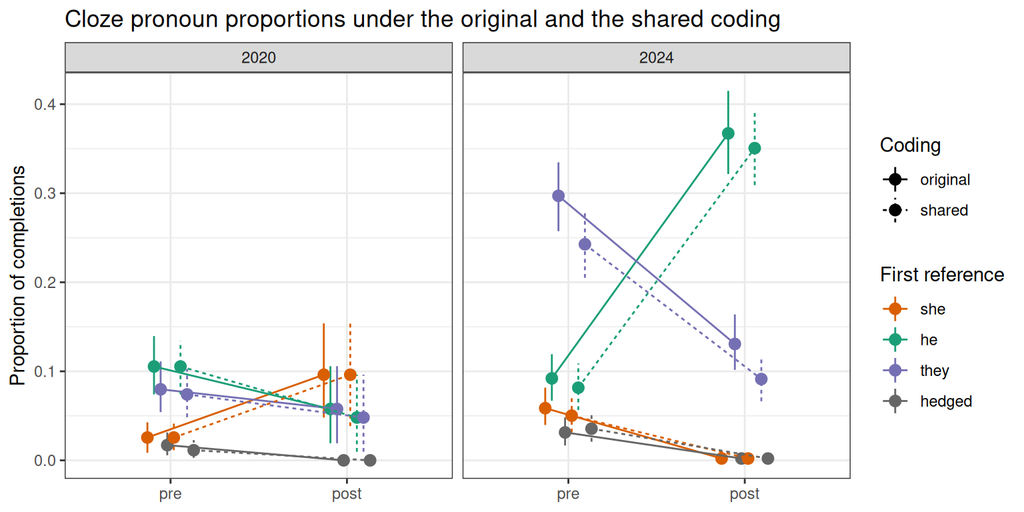

```r
bind_rows(
  shared = code_indicators(cloze_original, "cloze_code"),
  original = code_indicators(cloze_original, "original_as_shared"),
  .id = "coding"
) |>
  filter(code %in% pronoun_codes) |>
  ggplot(aes(x = round, y = present, color = code, linetype = coding,
             group = interaction(code, coding))) +
  line_with_errorbars(position_dodge(width = .3)) +
  facet_wrap(~study) +
  pronoun_code_scale +
  labs(x = NULL, y = "Proportion of completions", color = "First reference", linetype = "Coding",
       title = "Cloze pronoun proportions under the original and the shared coding")
```

# Reading times

```r
critical <- critical_words |>
  filter(session_id %in% kept_sessions)
# Missing RTs (2020 SPR logged a few as None) count as outside the window.
in_window <- coalesce(critical$rt >= params$rt_min & critical$rt <= params$rt_max, FALSE)
maze_ok <- !params$maze_correct_only | critical$task == "spr" | coalesce(critical$maze_correct, FALSE)
critical |>
  mutate(removed = !(in_window & maze_ok)) |>
  group_by(study, task) |>
  summarize(words = n(), prop_removed = round(mean(removed), 3), .groups = "drop") |>
  show_table("Critical-trial words removed by the RT window / Maze accuracy filter")
```

Critical-trial words removed by the RT window / Maze accuracy filter

| study | task | words | prop_removed |
| --- | --- | --- | --- |
| 2020 | maze | 33,229 | 0.033 |
| 2020 | mazerace | 15,792 | 0.035 |
| 2020 | spr | 49,185 | 0.009 |
| 2024 | maze | 25,283 | 0.030 |
| 2024 | spr | 44,963 | 0.007 |

```r
critical_rt <- critical[in_window & maze_ok, ]
```

RTs are plotted on a log scale, so means and CIs are computed on log RT (geometric means), which down-weights long RTs.

```r
# The log10 transform applies before stat_summary, so means are geometric means.
log_ms_axis <- scale_y_log10(name = "RT (ms, geometric mean)")

# Words in the given critical sentence, positioned relative to its pronoun.
relative_to_pronoun <- function(df, sentence, pronoun_flag) {
  pronoun_position <- df |>
    filter(sentence_index == sentence, .data[[pronoun_flag]]) |>
    select(session_id, pronoun_word = word_index_in_sentence)
  df |>
    filter(sentence_index == sentence) |>
    inner_join(pronoun_position, by = "session_id", relationship = "many-to-one") |>
    mutate(position = word_index_in_sentence - pronoun_word)
}

# Sentences differ in length and pronoun position, so far-out positions come
# from only some items. Keep positions present in at least half the sessions
# of each study x task.
well_covered_positions <- function(df) {
  df |>
    group_by(study, task) |>
    mutate(sessions = n_distinct(session_id)) |>
    group_by(study, task, position) |>
    filter(n_distinct(session_id) >= sessions / 2) |>
    ungroup() |>
    select(-sessions)
}

# Region words, relative to the pronoun: Maze, the pronoun itself; SPR, the
# pronoun and the next three words (spillover), each kept as its own word
# (not averaged) so the spillover positions can be compared.
region_positions <- list(maze = 0, spr = 0:3)
region_words <- function(df) {
  stopifnot(all(df$task %in% names(region_positions)))
  df |>
    filter(map2_lgl(task, position, \(tk, pos) pos %in% region_positions[[tk]])) |>
    mutate(word = factor(if_else(position == 0, "pronoun", paste0("pronoun +", position)),
                         levels = c("pronoun", paste0("pronoun +", 1:3))))
}

pronoun_2_pairs <- function(df) {
  mutate(df, pair = if_else(pro1_type == pro2_type, "match", "mismatch"))
}

reading_tasks <- c("maze", "spr")
s1 <- critical_rt |>
  filter(task %in% reading_tasks) |>
  relative_to_pronoun(1, "is_pro1")
s2 <- critical_rt |>
  filter(task %in% reading_tasks) |>
  relative_to_pronoun(2, "is_pro2") |>
  pronoun_2_pairs()
```

## Time courses

Whole critical sentences, aligned on the pronoun (0), in the **main** set. Positions are kept if at least half the sessions of that study and task have them. Pronoun 2 either matches pronoun 1 (he-he, she-she, they-they) or switches gender (he-she, she-he).

```r
plot_time_course_1 <- function(df, title) {
  ggplot(well_covered_positions(df), aes(x = position, y = rt, color = pro1_type, group = pro1_type)) +
    line_with_errorbars(dodge) +
    geom_vline(xintercept = 0, color = "grey70") +
    facet_grid(paste(study, task) ~ round, scales = "free") +
    pronoun_scale +
    log_ms_axis +
    labs(x = "Word position relative to pronoun 1", color = "Pronoun 1", title = title)
}
plot_time_course_2 <- function(df, title) {
  ggplot(well_covered_positions(df),
         aes(x = position, y = rt, color = pro2_type, linetype = pair, group = interaction(pro2_type, pair))) +
    line_with_errorbars(dodge) +
    geom_vline(xintercept = 0, color = "grey70") +
    facet_grid(paste(study, task) ~ round, scales = "free") +
    pronoun_scale +
    log_ms_axis +
    labs(x = "Word position relative to pronoun 2", color = "Pronoun 2", linetype = "Pronoun pair",
         title = title)
}
```

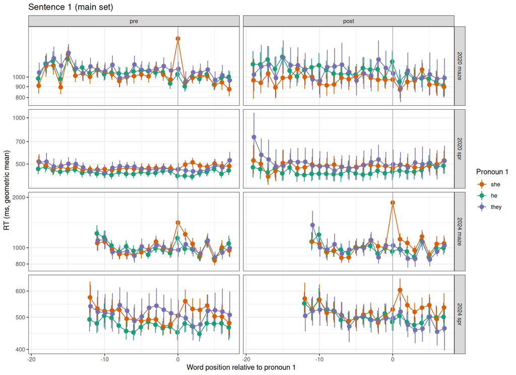

```r
plot_time_course_1(s1, paste0("Sentence 1 (", params$main_set, " set)"))
```

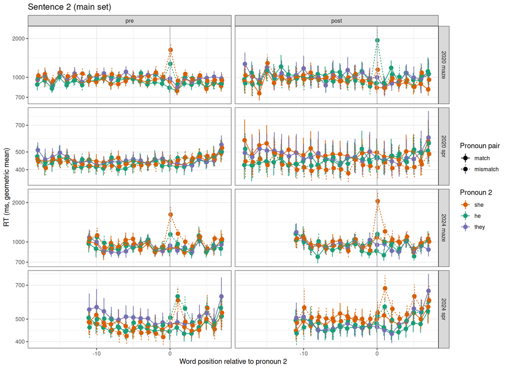

```r
plot_time_course_2(s2, paste0("Sentence 2 (", params$main_set, " set)"))
```

## Analysis region

Maze: RT at the pronoun. SPR: the pronoun and each of the next three words (spillover), shown separately. Values are per word, after the RT window (and, for Maze, the first-try accuracy filter).

```r
region_1 <- region_words(s1)
region_2 <- region_words(s2)
```

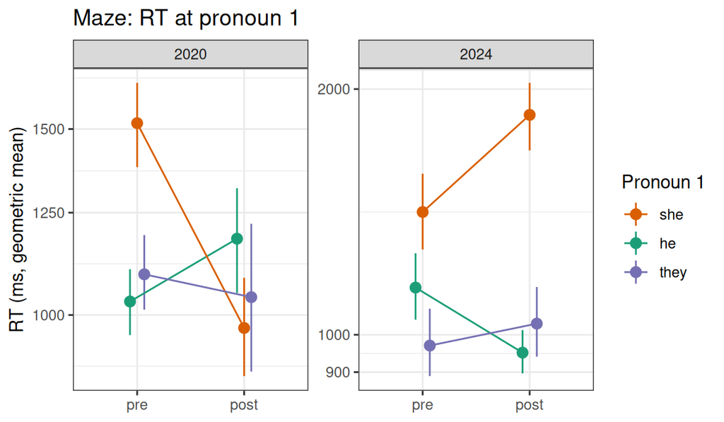

```r
ggplot(filter(region_1, task == "maze"), aes(x = round, y = rt, color = pro1_type, group = pro1_type)) +
  line_with_errorbars(dodge) +
  facet_wrap(~study, scales = "free_y") +
  pronoun_scale +
  log_ms_axis +
  labs(x = NULL, color = "Pronoun 1", title = "Maze: RT at pronoun 1")
```

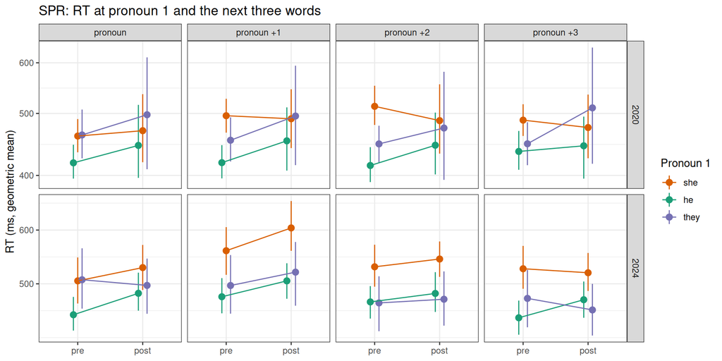

```r
ggplot(filter(region_1, task == "spr"), aes(x = round, y = rt, color = pro1_type, group = pro1_type)) +
  line_with_errorbars(dodge) +
  facet_grid(study ~ word, scales = "free_y") +
  pronoun_scale +
  log_ms_axis +
  labs(x = NULL, color = "Pronoun 1", title = "SPR: RT at pronoun 1 and the next three words")
```

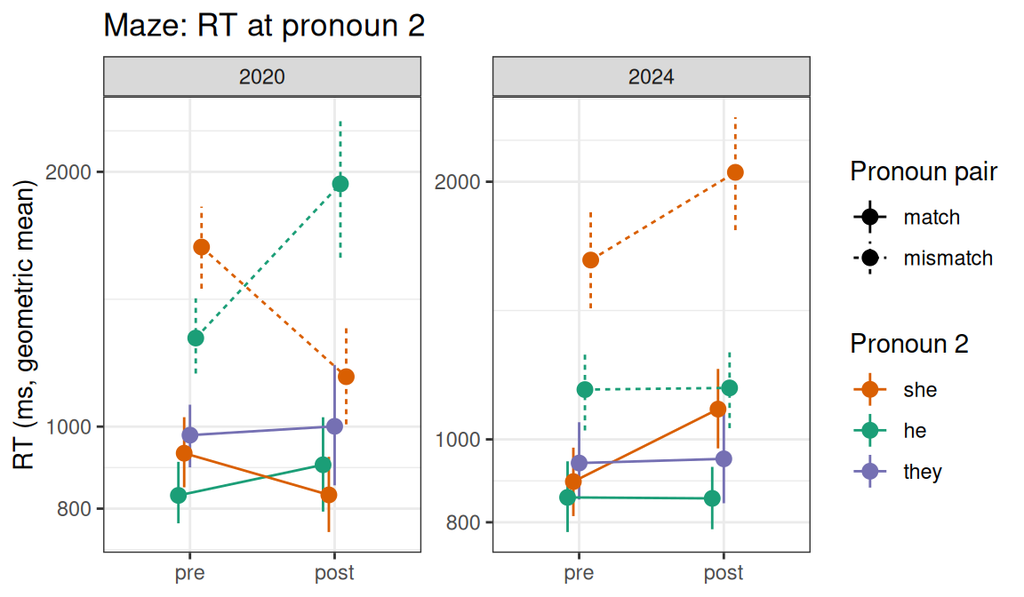

```r
ggplot(filter(region_2, task == "maze"), aes(x = round, y = rt, color = pro2_type,
                                             linetype = pair, group = interaction(pro2_type, pair))) +
  line_with_errorbars(dodge) +
  facet_wrap(~study, scales = "free_y") +
  pronoun_scale +
  log_ms_axis +
  labs(x = NULL, color = "Pronoun 2", linetype = "Pronoun pair", title = "Maze: RT at pronoun 2")
```

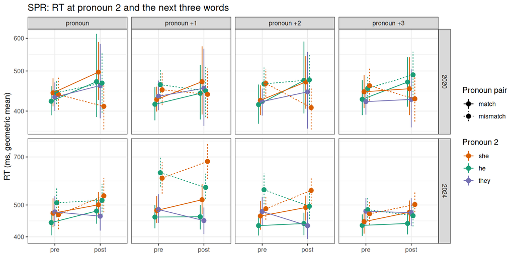

```r
ggplot(filter(region_2, task == "spr"), aes(x = round, y = rt, color = pro2_type,
                                            linetype = pair, group = interaction(pro2_type, pair))) +
  line_with_errorbars(dodge) +
  facet_grid(study ~ word, scales = "free_y") +
  pronoun_scale +
  log_ms_axis +
  labs(x = NULL, color = "Pronoun 2", linetype = "Pronoun pair",
       title = "SPR: RT at pronoun 2 and the next three words")
```

## Maze accuracy at the pronoun

Proportion of sessions choosing the pronoun correctly on the first try (all words, no RT window), in the **main** set.

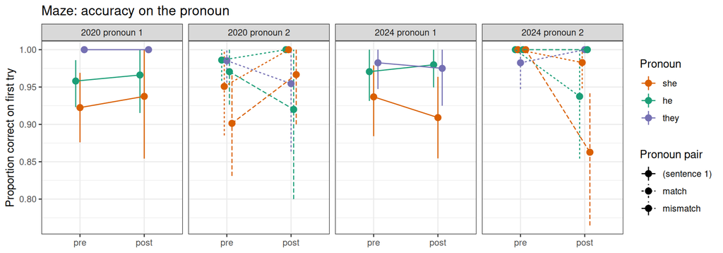

```r
maze_pronoun_words <- critical_words |>
  filter(task == "maze", is_pro1 | is_pro2) |>
  pronoun_2_pairs() |>
  mutate(pronoun = if_else(is_pro1, "pronoun 1", "pronoun 2"),
         pronoun_type = if_else(is_pro1, pro1_type, pro2_type),
         # Pronoun 1 is preceded only by sentence 1, so the pair is irrelevant there.
         pair = if_else(is_pro1, "(sentence 1)", pair))
ggplot(filter(maze_pronoun_words, session_id %in% kept_sessions), aes(x = round, y = as.numeric(maze_correct), color = pronoun_type,
                                  linetype = pair, group = interaction(pronoun_type, pair))) +
  line_with_errorbars(dodge) +
  facet_wrap(~ paste(study, pronoun), nrow = 1) +
  pronoun_scale +
  labs(x = NULL, y = "Proportion correct on first try", color = "Pronoun", linetype = "Pronoun pair",
       title = "Maze: accuracy on the pronoun")
```

## Mazerace (2020 only)

The context sentence is followed by “The vice president will be (a) black/white/Black/White (person) …”.

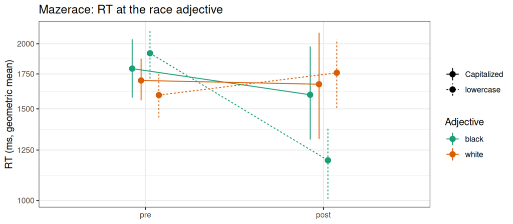

```r
race <- critical_rt |>
  filter(task == "mazerace", is_race_adjective) |>
  mutate(race = tolower(race_adjective),
         capitalized = if_else(race_adjective == str_to_title(race_adjective), "Capitalized", "lowercase"))
ggplot(race, aes(x = round, y = rt, color = race, linetype = capitalized,
                 group = interaction(race, capitalized))) +
  line_with_errorbars(dodge) +
  scale_color_brewer(palette = "Dark2") +
  log_ms_axis +
  labs(x = NULL, color = "Adjective", linetype = NULL, title = "Mazerace: RT at the race adjective")
```

# Recall

After the reading task, participants said whom the writer believed would win.

Split by the pronoun pair the participant read (pronoun 1 – pronoun 2).

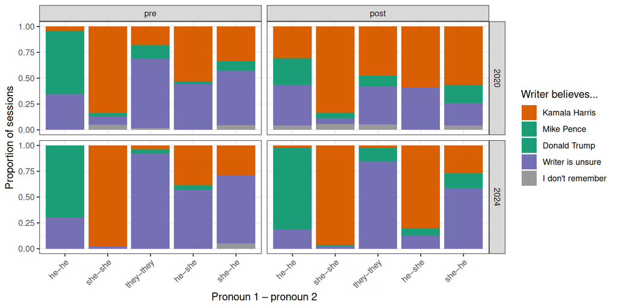

```r
pair_levels <- c("he–he", "she–she", "they–they", "he–she", "she–he")
recall_by_pronoun <- recall |>
  filter(session_id %in% kept_sessions) |>
  inner_join(distinct(filter(critical_words, task %in% reading_tasks), session_id, pro1_type, pro2_type),
             by = "session_id", relationship = "one-to-one") |>
  mutate(round = factor(round, levels = round_levels), study = as.character(study),
         pronoun_pair = factor(paste0(pro1_type, "–", pro2_type), levels = pair_levels))
stopifnot(!anyNA(recall_by_pronoun$pronoun_pair))
plot_recall <- function(df, facet, title = NULL) {
  df |>
    count(study, round, across(any_of("party")), pronoun_pair, recall_response) |>
    mutate(prop = n / sum(n), .by = c(study, round, any_of("party"), pronoun_pair)) |>
    mutate(recall_response = factor(recall_response, levels = names(recall_colors))) |>
    ggplot(aes(x = pronoun_pair, y = prop, fill = recall_response)) +
    geom_col() +
    facet +
    scale_fill_manual(values = recall_colors) +
    theme(axis.text.x = element_text(angle = 45, hjust = 1)) +
    labs(x = "Pronoun 1 – pronoun 2", y = "Proportion of sessions", fill = "Writer believes...", title = title)
}
plot_recall(recall_by_pronoun, facet_grid(study ~ round))
```

# Participants

```r
sessions |>
  filter(session_id %in% kept_sessions) |>
  group_by(study, round) |>
  summarize(
    n = n(),
    age_median = median(age, na.rm = TRUE),
    female = mean(gender == "Female", na.rm = TRUE),
    democrat = mean(political_affiliation == "Democrat", na.rm = TRUE),
    republican = mean(political_affiliation == "Republican", na.rm = TRUE),
    prefer_dem = mean(election_pref %in% c("Kamala Harris", "Joe Biden"), na.rm = TRUE),
    prefer_rep = mean(election_pref %in% c("Donald Trump", "Mike Pence"), na.rm = TRUE),
    .groups = "drop"
  ) |>
  mutate(across(female:prefer_rep, \(x) round(x, 2))) |>
  show_table("Kept sessions: demographics (proportions)")
```

Kept sessions: demographics (proportions)

| study | round | n | age_median | female | democrat | republican | prefer_dem | prefer_rep |
| --- | --- | --- | --- | --- | --- | --- | --- | --- |
| 2020 | pre | 1,540 | 36 | 0.45 | 0.47 | 0.25 | 0.62 | 0.31 |
| 2020 | post | 511 | 34 | 0.47 | 0.50 | 0.25 | 0.70 | 0.23 |
| 2024 | pre | 1,175 | 47 | 0.51 | 0.32 | 0.30 | 0.54 | 0.39 |
| 2024 | post | 1,177 | 47 | 0.51 | 0.33 | 0.28 | 0.55 | 0.38 |

```r
sessions |>
  filter(session_id %in% kept_sessions, study == "2020", round == "post") |>
  count(aware) |>
  mutate(prop = round(n / sum(n), 2)) |>
  show_table("2020 post-election: aware the race had been called?")
```

2020 post-election: aware the race had been called?

| aware | n | prop |
| --- | --- | --- |
| no | 15 | 0.03 |
| yes | 496 | 0.97 |

# By expected probability that the female candidate wins

Each session’s own event expectation, P(female candidate wins), against its critical-trial result, in the **main** set. Harris is the Democratic candidate in both studies, so this is `expect_prob_dem`. In 2020 the vice-presidency and presidency questions are pooled: Harris becomes vice president exactly when Biden wins. Sessions with all sliders at 0 have no expectation and are left out. Lines are per-session fits with 95% CIs: linear on log RT for RTs, logistic for cloze proportions. Dots are sessions (cloze: one dot per session per pronoun, at 0 or 1 with a little vertical jitter).

```r
p_female <- sessions |>
  filter(!is.na(expect_prob_dem)) |>
  select(session_id, p_female = expect_prob_dem)
with_p_female <- function(df) inner_join(df, p_female, by = "session_id", relationship = "many-to-one")
p_female_axis <- scale_x_continuous(name = "P(female candidate wins), participant's own estimate",
                                    limits = c(0, 1), breaks = c(0, .5, 1))
```

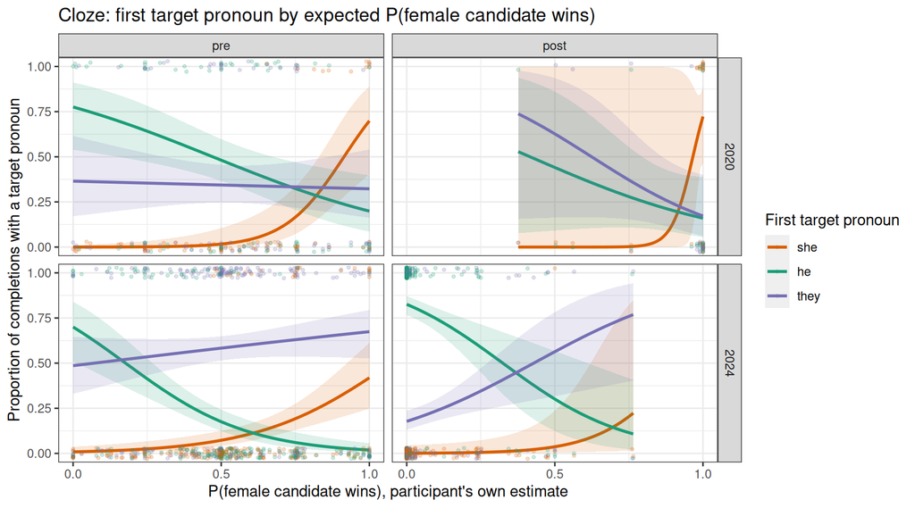

```r
# Denominator: completions with a target pronoun (including hedged ones,
# which are not plotted).
first_pronouns |>
  with_p_female() |>
  filter(code %in% names(pronoun_colors)) |>
  ggplot(aes(x = p_female, y = present, color = code, fill = code)) +
  geom_smooth(method = "glm", method.args = list(family = binomial), formula = y ~ x, alpha = .15) +
  # Outcomes are 0/1; a little vertical jitter shows how many sessions sit at each x.
  geom_point(position = position_jitter(width = 0, height = .03, seed = 1), alpha = .2, size = .8) +
  facet_grid(study ~ round) +
  pronoun_scale +
  scale_fill_manual(values = pronoun_colors, guide = "none") +
  p_female_axis +
  coord_cartesian(ylim = c(0, 1)) +
  labs(y = "Proportion of completions with a target pronoun", color = "First target pronoun",
       title = "Cloze: first target pronoun by expected P(female candidate wins)")
```

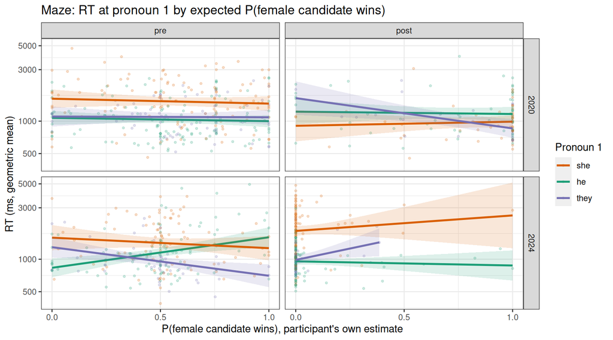

```r
ggplot(with_p_female(filter(region_1, task == "maze")),
       aes(x = p_female, y = rt, color = pro1_type, fill = pro1_type)) +
  geom_point(alpha = .2, size = .8) +
  geom_smooth(method = "lm", formula = y ~ x, alpha = .15) +
  facet_grid(study ~ round) +
  pronoun_scale +
  scale_fill_manual(values = pronoun_colors, guide = "none") +
  p_female_axis +
  log_ms_axis +
  labs(color = "Pronoun 1", title = "Maze: RT at pronoun 1 by expected P(female candidate wins)")
```

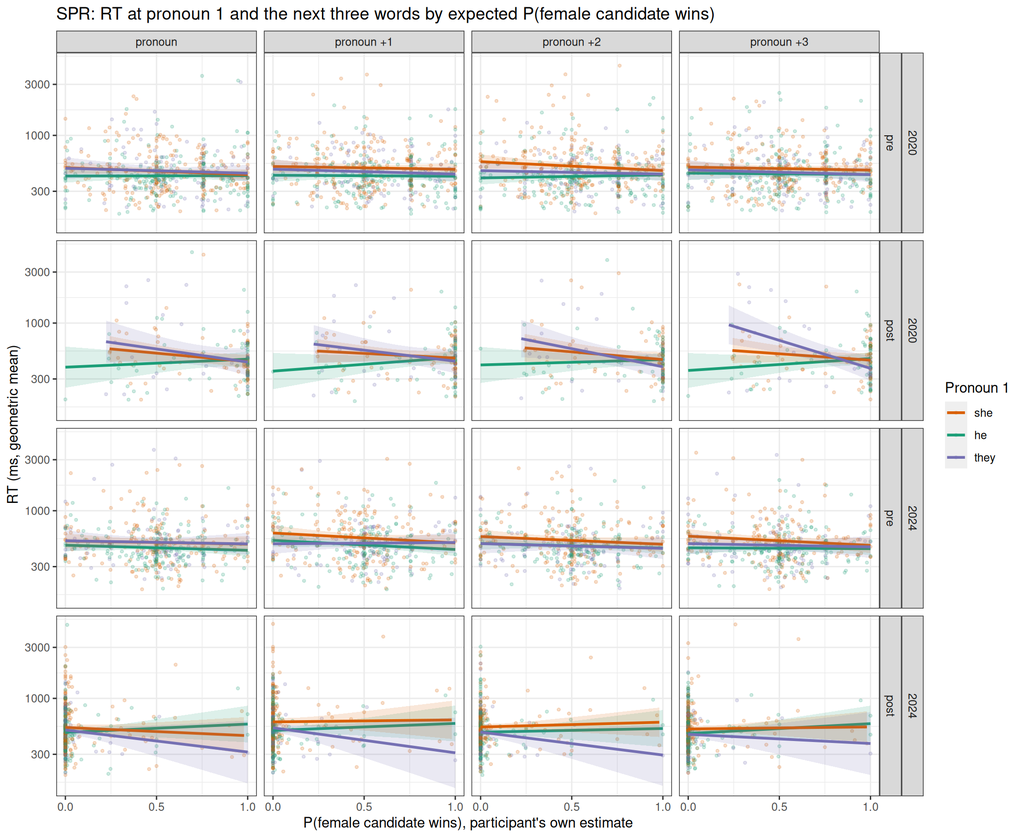

```r
ggplot(with_p_female(filter(region_1, task == "spr")),
       aes(x = p_female, y = rt, color = pro1_type, fill = pro1_type)) +
  geom_point(alpha = .2, size = .8) +
  geom_smooth(method = "lm", formula = y ~ x, alpha = .15) +
  facet_grid(study + round ~ word) +
  pronoun_scale +
  scale_fill_manual(values = pronoun_colors, guide = "none") +
  p_female_axis +
  log_ms_axis +
  labs(color = "Pronoun 1",
       title = "SPR: RT at pronoun 1 and the next three words by expected P(female candidate wins)")
```

# By political affiliation

The same summaries split by self-reported party affiliation, in the **main** set. “Other / none / didn’t say” pools “Other”, “None”, “Rather not say” and missing answers.

```r
party_levels <- c("Democrat", "Republican", "Independent", "other / none / didn't say")
party <- sessions |>
  transmute(session_id,
            party = factor(if_else(political_affiliation %in% party_levels[1:3], political_affiliation,
                                   party_levels[4]), levels = party_levels))
stopifnot(!anyNA(party$party))
with_party <- function(df) inner_join(df, party, by = "session_id", relationship = "many-to-one")
sessions |>
  filter(session_id %in% kept_sessions) |>
  with_party() |>
  count(study, round, party) |>
  pivot_wider(names_from = party, values_from = n, values_fill = 0) |>
  show_table("Sessions per party affiliation")
```

Sessions per party affiliation

| study | round | Democrat | Republican | Independent | other / none / didn’t say |
| --- | --- | --- | --- | --- | --- |
| 2020 | pre | 718 | 387 | 352 | 83 |
| 2020 | post | 256 | 127 | 106 | 22 |
| 2024 | pre | 372 | 348 | 430 | 25 |
| 2024 | post | 387 | 333 | 412 | 45 |

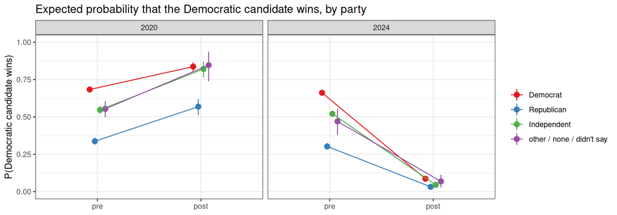

```r
expectation_plot_data |>
  with_party() |>
  ggplot(aes(x = round, y = expect_prob_dem, color = party, group = party)) +
  line_with_errorbars(dodge) +
  facet_wrap(~study) +
  scale_color_brewer(palette = "Set1") +
  coord_cartesian(ylim = c(0, 1)) +
  labs(x = NULL, y = "P(Democratic candidate wins)", color = NULL,
       title = "Expected probability that the Democratic candidate wins, by party")
```

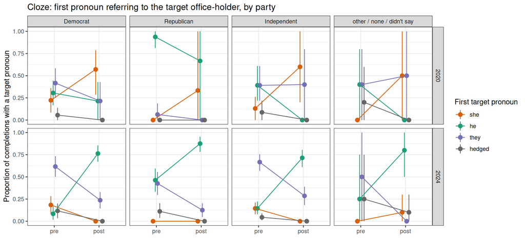

```r
first_pronouns |>
  with_party() |>
  ggplot(aes(x = round, y = present, color = code, group = code)) +
  line_with_errorbars(dodge) +
  facet_grid(study ~ party) +
  pronoun_code_scale +
  labs(x = NULL, y = "Proportion of completions with a target pronoun", color = "First target pronoun",
       title = "Cloze: first pronoun referring to the target office-holder, by party")
```

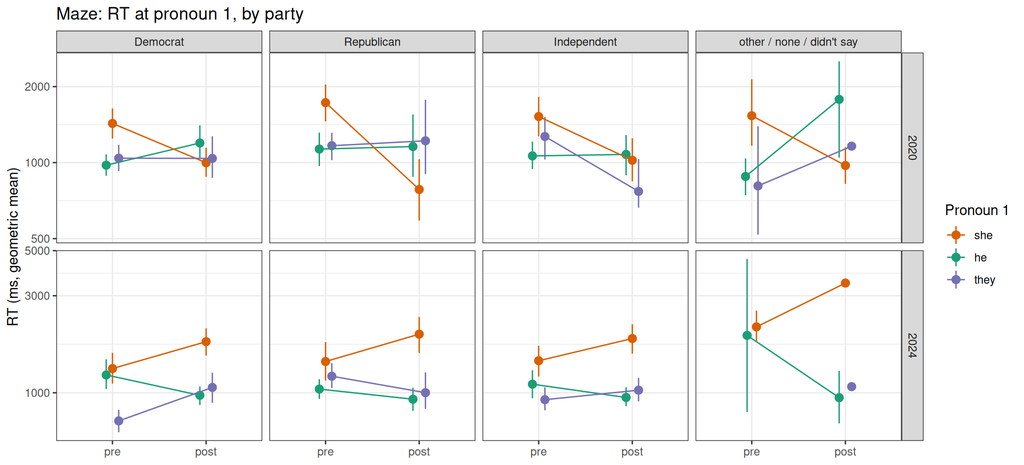

```r
ggplot(with_party(filter(region_1, task == "maze")), aes(x = round, y = rt, color = pro1_type, group = pro1_type)) +
  line_with_errorbars(dodge) +
  facet_grid(study ~ party, scales = "free_y") +
  pronoun_scale +
  log_ms_axis +
  labs(x = NULL, color = "Pronoun 1", title = "Maze: RT at pronoun 1, by party")
```

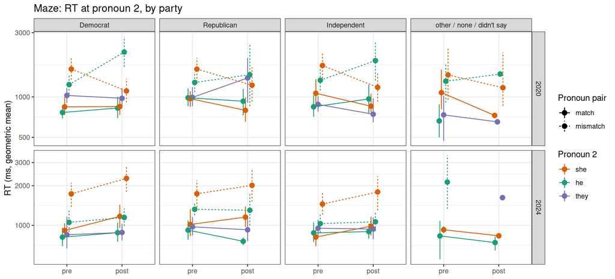

```r
ggplot(with_party(filter(region_2, task == "maze")), aes(x = round, y = rt, color = pro2_type, linetype = pair,
                                                         group = interaction(pro2_type, pair))) +
  line_with_errorbars(dodge) +
  facet_grid(study ~ party, scales = "free_y") +
  pronoun_scale +
  log_ms_axis +
  labs(x = NULL, color = "Pronoun 2", linetype = "Pronoun pair", title = "Maze: RT at pronoun 2, by party")
```

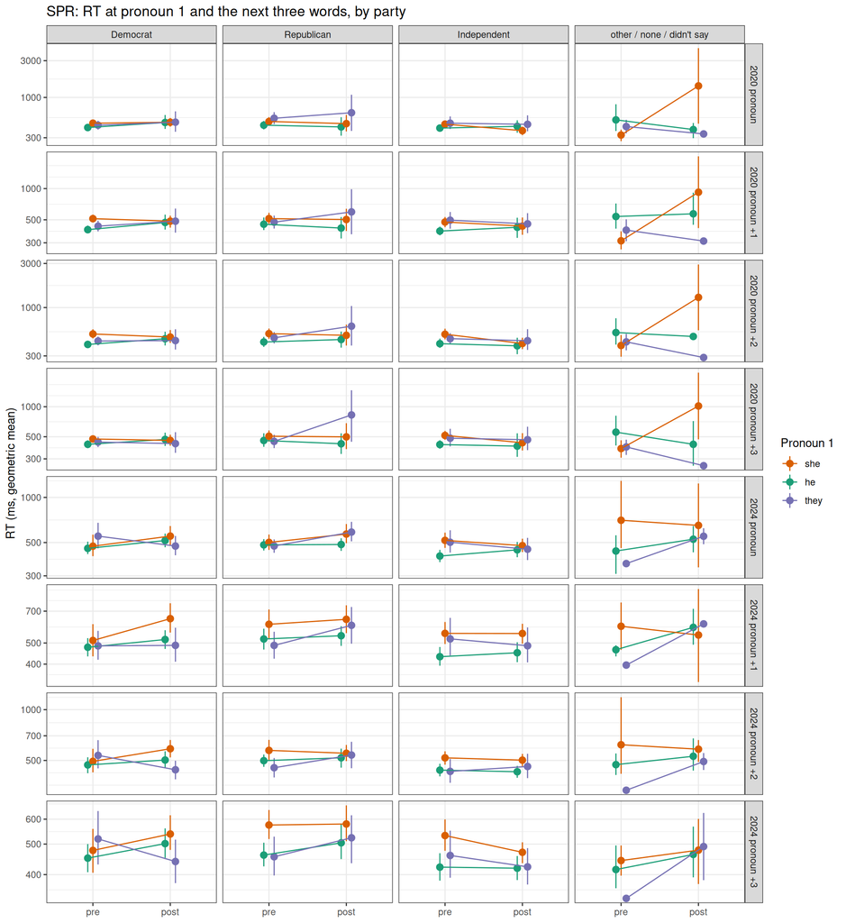

```r
ggplot(with_party(filter(region_1, task == "spr")), aes(x = round, y = rt, color = pro1_type, group = pro1_type)) +
  line_with_errorbars(dodge) +
  facet_grid(paste(study, word) ~ party, scales = "free_y") +
  pronoun_scale +
  log_ms_axis +
  labs(x = NULL, color = "Pronoun 1", title = "SPR: RT at pronoun 1 and the next three words, by party")
```

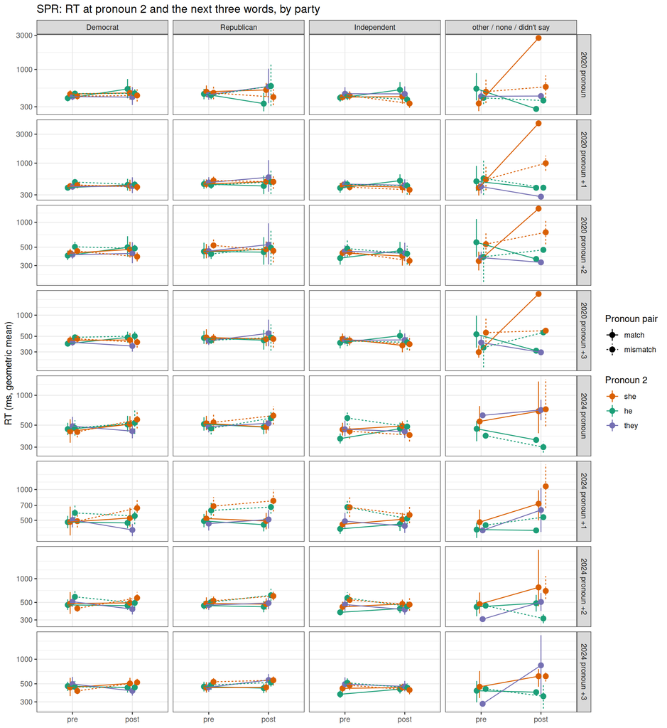

```r
ggplot(with_party(filter(region_2, task == "spr")), aes(x = round, y = rt, color = pro2_type, linetype = pair,
                                                        group = interaction(pro2_type, pair))) +
  line_with_errorbars(dodge) +
  facet_grid(paste(study, word) ~ party, scales = "free_y") +
  pronoun_scale +
  log_ms_axis +
  labs(x = NULL, color = "Pronoun 2", linetype = "Pronoun pair",
       title = "SPR: RT at pronoun 2 and the next three words, by party")
```

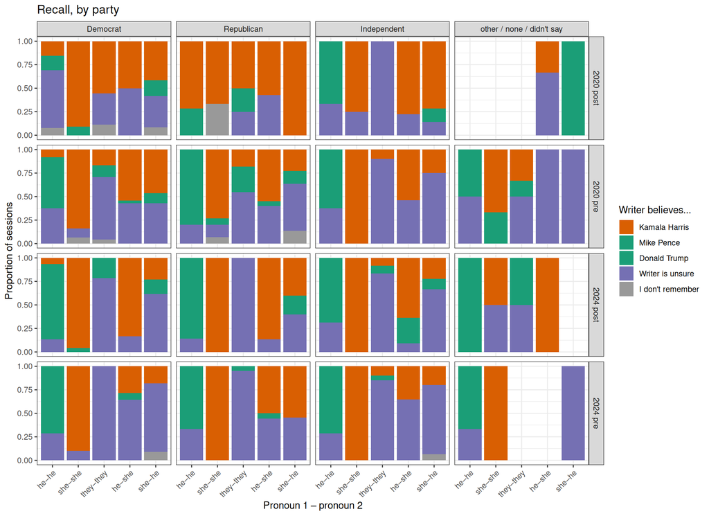

```r
recall_by_pronoun |>
  with_party() |>
  plot_recall(facet_grid(paste(study, round) ~ party), title = "Recall, by party")
```